# IODS course project

Balaguru Ravikumar

# About the project

The **Introduction to Open Data Science** is an excellent initative for graduate students like myself to explore the base aspects of reporducible research. The course through various workshop excercises faciliaties *hands-on* data anaylsis frameworks to explore and review. Further the peer-review process accompanied with every excercise would aid in understanding the excercise in a grave manner. My excercises and codes will be available for my peers from my [Git repository](https://github.com/BalaguruRavikumar/IODS-project.git).

## **Tools and Methods for open and reproducible research**

Git repository and the course dairy pages were prepared and updated as per the requirments. The Datacamp excerise **“*R Short and Sweet*”** was completed [link](https://www.datacamp.com/statement-of-accomplishment/course/0baf9ad88eb1f86a2c08ebd1ed2ef24d0a7ef2f9) prior to the final commit.

# **Regression and Model validation**

## Summary

- Prior to starting the **“*RStudio Exercise 2*”** I have completed the DataCamp excerise **“Regression and model validation”**, wherein functionalities such as handling dataframes (reading, writing, selecting and plotting) were well understood. Apart from exploring, fitting and predicting using linear regression models, I have also familiarized with apporaches to model validation.
- The analysis dataset for the **“*RStudio Exercise 2*”** was generated following the **Data Wrangling** protocol where in a dataframe *learning2014* data was processed such that it contains 166 rows and 7 columns.

## Procedure for Exercise 2

### Reading the data:

```r
lrn2014 <- read.table('data/learning2014.txt', header=TRUE)
head(lrn2014, n = 10)
```

```
##    gender age attitude     deep  stra     surf points
## 1       F  53       37 3.583333 3.375 2.583333     25
## 2       M  55       31 2.916667 2.750 3.166667     12
## 3       F  49       25 3.500000 3.625 2.250000     24
## 4       M  53       35 3.500000 3.125 2.250000     10
## 5       M  49       37 3.666667 3.625 2.833333     22
## 6       F  38       38 4.750000 3.625 2.416667     21
## 7       M  50       35 3.833333 2.250 1.916667     21
## 8       F  37       29 3.250000 4.000 2.833333     31
## 9       M  37       38 4.333333 4.250 2.166667     24
## 10      F  42       21 4.000000 3.500 3.000000     26
```

#### Exploring the data:

- This initial dataset documents the responses from 183 students complied as a part of a survey on teaching and learning that was conducted as a research project made possible by the **Academy of Sciences**. Certain missing values of some backgrounds were imputed.
- The initial dataset was curated such that it contains 166 respondents and 7 factors. Factors/Parameters such as **age, gender, attitutde, deep questions, durface questions, strategic questions and the exam points secured by the students** are given as column names.
- Further curation was carried such that only the avergae values from questionaries *deep questions, durface questions, strategic questions* were used and only responder with exam points *greater than zero* are used, resulting 166 respondents over 7 factors.
- A brief overview of the analysis data is given below.

```r
str(lrn2014)
```

```
## 'data.frame':    166 obs. of  7 variables:
##  $ gender  : Factor w/ 2 levels "F","M": 1 2 1 2 2 1 2 1 2 1 ...
##  $ age     : int  53 55 49 53 49 38 50 37 37 42 ...
##  $ attitude: int  37 31 25 35 37 38 35 29 38 21 ...
##  $ deep    : num  3.58 2.92 3.5 3.5 3.67 ...
##  $ stra    : num  3.38 2.75 3.62 3.12 3.62 ...
##  $ surf    : num  2.58 3.17 2.25 2.25 2.83 ...
##  $ points  : int  25 12 24 10 22 21 21 31 24 26 ...
```

```r
colnames(lrn2014)
```

```
## [1] "gender"   "age"      "attitude" "deep"     "stra"     "surf"
## [7] "points"
```

### Graphical overview and summary of the data:

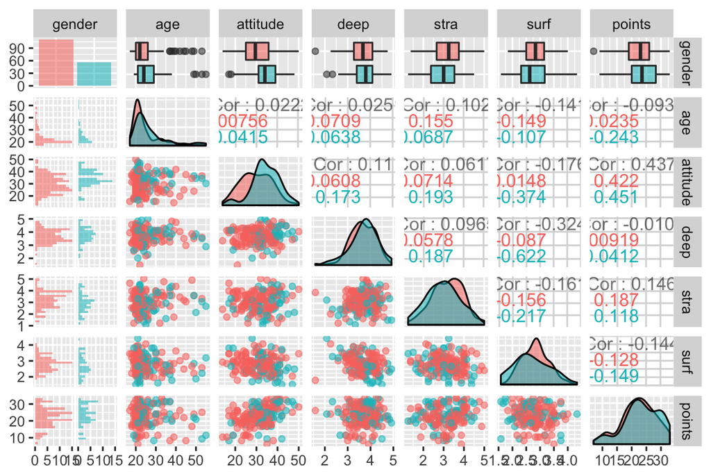

```
##  gender       age           attitude          deep            stra
##  F:110   Min.   :17.00   Min.   :14.00   Min.   :1.583   Min.   :1.250
##  M: 56   1st Qu.:21.00   1st Qu.:26.00   1st Qu.:3.333   1st Qu.:2.625
##          Median :22.00   Median :32.00   Median :3.667   Median :3.188
##          Mean   :25.51   Mean   :31.43   Mean   :3.680   Mean   :3.121
##          3rd Qu.:27.00   3rd Qu.:37.00   3rd Qu.:4.083   3rd Qu.:3.625
##          Max.   :55.00   Max.   :50.00   Max.   :4.917   Max.   :5.000
##       surf           points
##  Min.   :1.583   Min.   : 7.00
##  1st Qu.:2.417   1st Qu.:19.00
##  Median :2.833   Median :23.00
##  Mean   :2.787   Mean   :22.72
##  3rd Qu.:3.167   3rd Qu.:27.75
##  Max.   :4.333   Max.   :33.00
```

### Fitting a linear regression model:

```r
my_model1 <- lm(points ~ attitude + deep + age, data = lrn2014)
summary(my_model1)
```

```
##
## Call:
## lm(formula = points ~ attitude + deep + age, data = lrn2014)
##
## Residuals:
##     Min      1Q  Median      3Q     Max
## -17.206  -3.430   0.204   3.979  10.950
##
## Coefficients:
##             Estimate Std. Error t value Pr(>|t|)
## (Intercept) 15.60773    3.38966   4.605 8.32e-06 ***
## attitude     0.35941    0.05696   6.310 2.56e-09 ***
## deep        -0.60275    0.75031  -0.803    0.423
## age         -0.07716    0.05322  -1.450    0.149
## ---
## Signif. codes:  0 '***' 0.001 '**' 0.01 '*' 0.05 '.' 0.1 ' ' 1
##
## Residual standard error: 5.307 on 162 degrees of freedom
## Multiple R-squared:  0.2043, Adjusted R-squared:  0.1896
## F-statistic: 13.87 on 3 and 162 DF,  p-value: 4.305e-08
```

```r
my_model2 <- lm(points ~ attitude + stra + surf, data = lrn2014)
summary(my_model2)
```

```
##
## Call:
## lm(formula = points ~ attitude + stra + surf, data = lrn2014)
##
## Residuals:
##      Min       1Q   Median       3Q      Max
## -17.1550  -3.4346   0.5156   3.6401  10.8952
##
## Coefficients:
##             Estimate Std. Error t value Pr(>|t|)
## (Intercept) 11.01711    3.68375   2.991  0.00322 **
## attitude     0.33952    0.05741   5.913 1.93e-08 ***
## stra         0.85313    0.54159   1.575  0.11716
## surf        -0.58607    0.80138  -0.731  0.46563
## ---
## Signif. codes:  0 '***' 0.001 '**' 0.01 '*' 0.05 '.' 0.1 ' ' 1
##
## Residual standard error: 5.296 on 162 degrees of freedom
## Multiple R-squared:  0.2074, Adjusted R-squared:  0.1927
## F-statistic: 14.13 on 3 and 162 DF,  p-value: 3.156e-08
```

The dependent/target variable used in the above model are the exam points obtained by the students, the independent/explanatory variable are various parameters such as attitute, age, and marks of questionaries from deep, statergic and surface questions. The objective is to use these explanatory variables to explain the distribution of exam points. The model being a multiple-linear model there are co-efficients (alpha) for the intercept and the various explanatory variables (Beta1, Beta2 and Beta3). The significance of these co-efficients are highlithed by the associated P-values and t values. There are various levels of significance (90%, 95% and 99%) indicated as * signs. These P-values are generated from a null distribution which gives us the risk of obatining such estimates for the co-efficients by chance. Apart from attitude all the other explanatory variables were found to be insignificant, as shown in the summary of generated models **my_models 1 & 2**.

### Parameter relationships:

The **Multiple R-squared** value of the models were close to 0.205. Thus the currently implemented multiple regression model is only 20.5% successful in predicting the depenedent **points** variable. Ths value might increase or decrease with the addition of new parameters. To avoid case of model overfitting one must look into the **Adjusted R-squared** as it penalizes for the number of independent variables used to explain the data. In both the case it is always better to have a larger R-squared value, as the model will be more likely to predict the outcomes successfully.

### Diagnostic Plots:

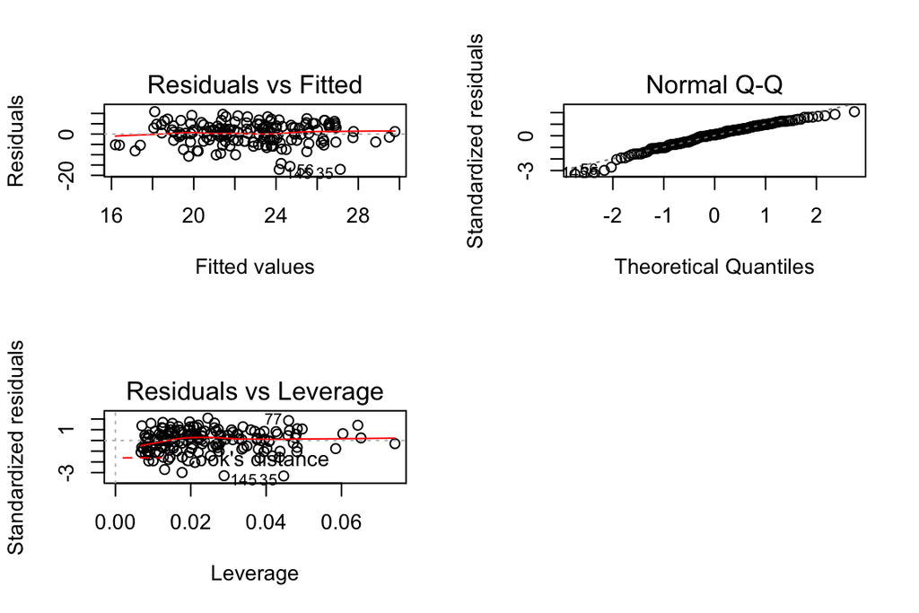

```r
par(mfrow = c(2,2))
plot(my_model2, which = c(1,2,5))
```

#### Model Assumptions:

# **Logistic regression**

## Summary

- Prior to starting the **“*RStudio Exercise 3*”** I have completed the DataCamp excerise **“Logistic regression”**, wherein functionalities such as handling data (combining, mutating, selecting, filtering) were well understood. Apart from exploring, fitting and predicting using logistic regression models, I have also familiarized with apporaches to model validation.
- The analysis dataset for the **“*RStudio Exercise 3*”** was generated following the **Data Wrangling** protocol where in a dataframe *alc* data was processed such that it contains 382 rows and 35 variables.

## Procedure for Exercise 3

### Libraries:

```r
library(dplyr)
```

```r
library(tidyr)
library(ggplot2)
library(boot)
```

### Reading the data:

```r
alc <- read.table('data/alc_data.txt', header=TRUE)
glimpse(alc)
```

```
## Observations: 382
## Variables: 35
## $ school     <fctr> GP, GP, GP, GP, GP, GP, GP, GP, GP, GP, GP, GP, GP...
## $ sex        <fctr> F, F, F, F, F, M, M, F, M, M, F, F, M, M, M, F, F,...
## $ age        <int> 18, 17, 15, 15, 16, 16, 16, 17, 15, 15, 15, 15, 15,...
## $ address    <fctr> U, U, U, U, U, U, U, U, U, U, U, U, U, U, U, U, U,...
## $ famsize    <fctr> GT3, GT3, LE3, GT3, GT3, LE3, LE3, GT3, LE3, GT3, ...
## $ Pstatus    <fctr> A, T, T, T, T, T, T, A, A, T, T, T, T, T, A, T, T,...
## $ Medu       <int> 4, 1, 1, 4, 3, 4, 2, 4, 3, 3, 4, 2, 4, 4, 2, 4, 4, ...
## $ Fedu       <int> 4, 1, 1, 2, 3, 3, 2, 4, 2, 4, 4, 1, 4, 3, 2, 4, 4, ...
## $ Mjob       <fctr> at_home, at_home, at_home, health, other, services...
## $ Fjob       <fctr> teacher, other, other, services, other, other, oth...
## $ reason     <fctr> course, course, other, home, home, reputation, hom...
## $ nursery    <fctr> yes, no, yes, yes, yes, yes, yes, yes, yes, yes, y...
## $ internet   <fctr> no, yes, yes, yes, no, yes, yes, no, yes, yes, yes...
```

[output cut: 22 more lines]

```r
colnames(alc)
```

```
##  [1] "school"     "sex"        "age"        "address"    "famsize"
##  [6] "Pstatus"    "Medu"       "Fedu"       "Mjob"       "Fjob"
## [11] "reason"     "nursery"    "internet"   "guardian"   "traveltime"
## [16] "studytime"  "failures"   "schoolsup"  "famsup"     "paid"
## [21] "activities" "higher"     "romantic"   "famrel"     "freetime"
## [26] "goout"      "Dalc"       "Walc"       "health"     "absences"
## [31] "G1"         "G2"         "G3"         "alc_use"    "high_use"
```

#### Exploring the data:

- The data is obtained from a series of questionaries from two Portuguese Schools with 382 students with 33 varibales (2 variables are added later).
- The preformace of students in two subjects Maths and Portuguese are provided.
- The dataset contains attributes such as **age, sex, family size, internet, romantic, paid and other binary variable** shown through the *glimpse* function, the continous varibles are **grades secured by the students in three different periods along with alcohol consumptions workday/weekday**.
- The alcohol consumptions were further categorized as **high/low consumptions** such that the avergae alcohol consumptions workday/weekday is **greater than 2**.

#### Data Analysis:

```r
my_var <- c("famsize" , "romantic", "freetime","goout")
my_model <- glm(high_use ~ famsize + romantic + freetime + goout, data = alc, family = "binomial")
```

##### Variable hypothesis:

- Family size (**famsize**) I hypothesize that students in a bigger family size will be prone to drink more.
- The romantic relationship (**romantic**) status yes/no, of the students might have an influence on the degree of alcohol consumptions, as I hypothesize that student would are in a romantic relationship would be porne to drink more.
- Free-time (**freetime**) varibale would have an underlying effcet on alcohol consumptions, as I hypothesize that students with more freetime would be prone to high level of alcohol consumption.
- Going-out (**goout**) varaible determines the friends cricle of students and I hypothesize that students how go-out more would be prone to high level of alcohol consumption.

#### Numerical and Graphical exploration the data:

```r
alc_data <- select(alc, one_of(c(my_var,"high_use")))
summary(alc_data)
```

```
##  famsize   romantic     freetime        goout        high_use
##  GT3:278   no :261   Min.   :1.00   Min.   :1.000   Mode :logical
##  LE3:104   yes:121   1st Qu.:3.00   1st Qu.:2.000   FALSE:268
##                      Median :3.00   Median :3.000   TRUE :114
##                      Mean   :3.22   Mean   :3.113
##                      3rd Qu.:4.00   3rd Qu.:4.000
##                      Max.   :5.00   Max.   :5.000
```

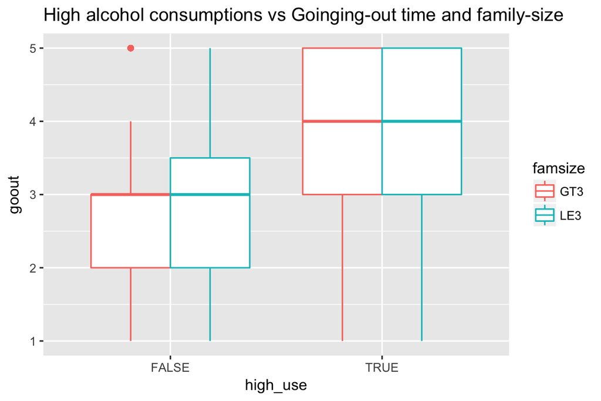

```r
ggplot(alc_data, aes(x = high_use, y = goout, col = famsize)) +geom_boxplot() + ggtitle("High alcohol consumptions vs Goinging-out time and family-size")
```

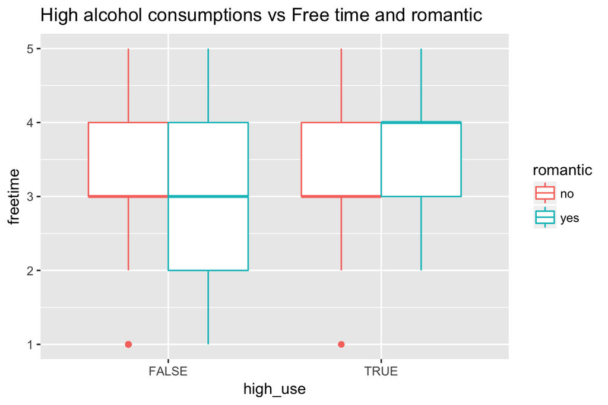

```r
ggplot(alc_data, aes(x = high_use, y = freetime, col = romantic)) + geom_boxplot() + ggtitle("High alcohol consumptions vs Free time and romantic")
```

#### Comments on my hypothesis:

- The explanatory variable going-out (**goout**) with friends, was higher in cases of high alc use whereas the family-size (**famsize**) had no effect of the high alc use.
- Similary the varibale free-time (**freetime**) by iteslf had no effect on the high alc use, but students in a romantic relationship (**romantic**) had higher free time and were porne to high alc use.

#### Logistic regression:

```r
log_model <- glm(high_use ~ famsize + romantic + freetime + goout, data = alc_data, family = "binomial")
summary(log_model)
```

```
##
## Call:
## glm(formula = high_use ~ famsize + romantic + freetime + goout,
##     family = "binomial", data = alc_data)
##
## Deviance Residuals:
##     Min       1Q   Median       3Q      Max
## -1.5554  -0.7900  -0.5379   0.9899   2.4649
##
## Coefficients:
##             Estimate Std. Error z value Pr(>|z|)
## (Intercept)  -3.7135     0.5393  -6.885 5.76e-12 ***
## famsizeLE3    0.3968     0.2641   1.502    0.133
## romanticyes  -0.2638     0.2644  -0.998    0.318
## freetime      0.1286     0.1319   0.975    0.330
## goout         0.7315     0.1204   6.075 1.24e-09 ***
## ---
## Signif. codes:  0 '***' 0.001 '**' 0.01 '*' 0.05 '.' 0.1 ' ' 1
##
## (Dispersion parameter for binomial family taken to be 1)
##
##     Null deviance: 465.68  on 381  degrees of freedom
## Residual deviance: 411.63  on 377  degrees of freedom
## AIC: 421.63
##
## Number of Fisher Scoring iterations: 4
```

```r
OR <- coef(log_model) %>% exp
CI <- confint(log_model) %>% exp
cbind(OR,CI)
```

```
##                     OR       2.5 %     97.5 %
## (Intercept) 0.02439252 0.008158479 0.06787269
## famsizeLE3  1.48704676 0.882770026 2.49225699
## romanticyes 0.76810291 0.453342164 1.28131049
## freetime    1.13718714 0.878467903 1.47520308
## goout       2.07829869 1.651370444 2.65038452
```

#### Interpret the results:

- From the summary of the model the explanatory variables that was evident in explaining the high alcohol consumption was the **goout** variables which along with the intercept had a higher lievel of significance shown through the P-values.
- Based on my hypothesis all the other variables expect **goout** failed to explain the high alc use.
- Based on the exponents of the coefficients values of the models i.e, **Odds Ratio** It was possible to ascertain that variables **(famsize (less than 3), freetime and goout)** having OR’s > 1 are positively asscoiated to successfuly association with high alc use, whereas **romantic** relationship presence was not sufficient to explain the high alc use.
- The variables **(famsize and romantic)** are factor variables shown through the str(alc_data) command. For these variables the coef values are intrepretted as their difference from the intercept.
- Through the CI caluctaion it can be found that the OR’s at 95% confidence (2.5% left tail and 97.5% right tail), we can be say the such OR values of the our explanatory variables in the model has 95% probability to fall between the ranges given in the columns **(2.5 & 97.5)**

#### Model predictions:

```r
log_model2 <- glm(high_use ~ goout, data = alc_data, family = "binomial")
probabilities <- predict(log_model2, type = "response")
alc_data <- mutate(alc_data, probability = probabilities)
alc_data <- mutate(alc_data, prediction = probability > 0.5)
table(high_use = alc_data$high_use, prediction = alc_data$prediction)
```

```
##         prediction
## high_use FALSE TRUE
##    FALSE   247   21
##    TRUE     82   32
```

```r
loss_func <- function(class, prob) {
  n_wrong <- abs(class - prob) > 0.5
  mean(n_wrong)
}
loss_func(class = alc_data$high_use, prob = alc_data$probability)
```

```
## [1] 0.2696335
```

```r
log_model3 <- glm(high_use ~ freetime, data = alc_data, family = "binomial")
probabilities <- predict(log_model3, type = "response")
alc_data <- mutate(alc_data, probability = probabilities)
alc_data <- mutate(alc_data, prediction = probability > 0.5)
table(high_use = alc_data$high_use, prediction = alc_data$prediction)
```

```
##         prediction
## high_use FALSE
##    FALSE   268
##    TRUE    114
```

```r
loss_func <- function(class, prob) {
  n_wrong <- abs(class - prob) > 0.5
  mean(n_wrong)
}
loss_func(class = alc_data$high_use, prob = alc_data$probability)
```

```
## [1] 0.2984293
```

#### Cross-validation (Bonus):

```r
cv <- cv.glm(data = alc_data, cost = loss_func, glmfit = log_model2, K = 10)
cv$delta[1]
```

```
## [1] 0.2696335
```

#### Comments:

- The model after 10 fold Cross-validation has a similar penalty as log_model2 and their loss penalities were 0.26.
- Yes, using the **goout** variable, I was able to find a similar model.

#### Cross-validation (Different logistic models-Super bonus):

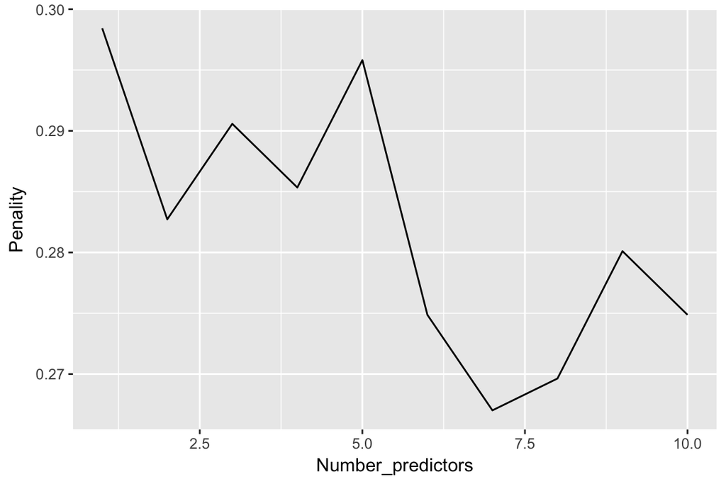

```r
get_log_model <- function(mydata){
  mymod <- glm(high_use ~ ., data = mydata, family = "binomial")
  cv <- cv.glm(data = mydata, cost = loss_func, glmfit = mymod, K = 10)
  return(cv$delta[1])
}

cv_values <- c()
cnames <- c("famrel", "internet", "age", "paid", "school", "Pstatus", "famsup", "romantic", "absences", "address")
predictors <- cnames
for( i in length(predictors):1){
    tempdata <- select(alc, one_of(c(predictors[i:length(predictors)],"high_use")))
    cv_values[i] <- get_log_model(tempdata)
}

results <- as.data.frame(cbind(Number_predictors = 10:1, Penality = cv_values))
ggplot(results, aes(x = Number_predictors, y = Penality))+geom_line()
```

#### Comments:

# **Clustering and Classification**

## Analysis Dataset:

- The boston data set contains 506 rows and 14 columns. The dataset contains various statistics about the boston area, which includes various factors like crime rate, business areas, popoulation, age and other similar variables.
- Most of the varaibles in the dataset are continoius values with few categorical variables.
- The summary of the various varibales are given below.

## Procedure for Exercise 4

### Libraries:

```r
library(MASS)
```

```r
library(corrplot)
library(GGally)
library(ggplot2)
```

### Loading the data:

```r
dim(Boston)
```

```
## [1] 506  14
```

```r
str(Boston)
```

```
## 'data.frame':    506 obs. of  14 variables:
##  $ crim   : num  0.00632 0.02731 0.02729 0.03237 0.06905 ...
##  $ zn     : num  18 0 0 0 0 0 12.5 12.5 12.5 12.5 ...
##  $ indus  : num  2.31 7.07 7.07 2.18 2.18 2.18 7.87 7.87 7.87 7.87 ...
##  $ chas   : int  0 0 0 0 0 0 0 0 0 0 ...
##  $ nox    : num  0.538 0.469 0.469 0.458 0.458 0.458 0.524 0.524 0.524 0.524 ...
##  $ rm     : num  6.58 6.42 7.18 7 7.15 ...
##  $ age    : num  65.2 78.9 61.1 45.8 54.2 58.7 66.6 96.1 100 85.9 ...
##  $ dis    : num  4.09 4.97 4.97 6.06 6.06 ...
##  $ rad    : int  1 2 2 3 3 3 5 5 5 5 ...
##  $ tax    : num  296 242 242 222 222 222 311 311 311 311 ...
##  $ ptratio: num  15.3 17.8 17.8 18.7 18.7 18.7 15.2 15.2 15.2 15.2 ...
##  $ black  : num  397 397 393 395 397 ...
##  $ lstat  : num  4.98 9.14 4.03 2.94 5.33 ...
##  $ medv   : num  24 21.6 34.7 33.4 36.2 28.7 22.9 27.1 16.5 18.9 ...
```

#### Summary and graphical overview of the data:

```r
summary(Boston)
```

```
##       crim                zn             indus            chas
##  Min.   : 0.00632   Min.   :  0.00   Min.   : 0.46   Min.   :0.00000
##  1st Qu.: 0.08204   1st Qu.:  0.00   1st Qu.: 5.19   1st Qu.:0.00000
##  Median : 0.25651   Median :  0.00   Median : 9.69   Median :0.00000
##  Mean   : 3.61352   Mean   : 11.36   Mean   :11.14   Mean   :0.06917
##  3rd Qu.: 3.67708   3rd Qu.: 12.50   3rd Qu.:18.10   3rd Qu.:0.00000
##  Max.   :88.97620   Max.   :100.00   Max.   :27.74   Max.   :1.00000
##       nox               rm             age              dis
##  Min.   :0.3850   Min.   :3.561   Min.   :  2.90   Min.   : 1.130
##  1st Qu.:0.4490   1st Qu.:5.886   1st Qu.: 45.02   1st Qu.: 2.100
##  Median :0.5380   Median :6.208   Median : 77.50   Median : 3.207
##  Mean   :0.5547   Mean   :6.285   Mean   : 68.57   Mean   : 3.795
##  3rd Qu.:0.6240   3rd Qu.:6.623   3rd Qu.: 94.08   3rd Qu.: 5.188
##  Max.   :0.8710   Max.   :8.780   Max.   :100.00   Max.   :12.127
##       rad              tax           ptratio          black
##  Min.   : 1.000   Min.   :187.0   Min.   :12.60   Min.   :  0.32
##  1st Qu.: 4.000   1st Qu.:279.0   1st Qu.:17.40   1st Qu.:375.38
##  Median : 5.000   Median :330.0   Median :19.05   Median :391.44
##  Mean   : 9.549   Mean   :408.2   Mean   :18.46   Mean   :356.67
##  3rd Qu.:24.000   3rd Qu.:666.0   3rd Qu.:20.20   3rd Qu.:396.23
##  Max.   :24.000   Max.   :711.0   Max.   :22.00   Max.   :396.90
##      lstat            medv
##  Min.   : 1.73   Min.   : 5.00
##  1st Qu.: 6.95   1st Qu.:17.02
##  Median :11.36   Median :21.20
##  Mean   :12.65   Mean   :22.53
##  3rd Qu.:16.95   3rd Qu.:25.00
##  Max.   :37.97   Max.   :50.00
```

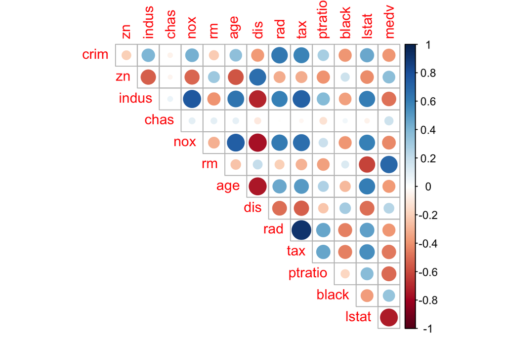

```r
corrplot(cor(Boston), method = "circle", type="upper", diag=FALSE)
```

##### Standardize the Dataset and create categorical varaible:

```r
bscaled <- as.data.frame(scale(Boston))
summary(bscaled)
```

```
##       crim                 zn               indus
##  Min.   :-0.419367   Min.   :-0.48724   Min.   :-1.5563
##  1st Qu.:-0.410563   1st Qu.:-0.48724   1st Qu.:-0.8668
##  Median :-0.390280   Median :-0.48724   Median :-0.2109
##  Mean   : 0.000000   Mean   : 0.00000   Mean   : 0.0000
##  3rd Qu.: 0.007389   3rd Qu.: 0.04872   3rd Qu.: 1.0150
##  Max.   : 9.924110   Max.   : 3.80047   Max.   : 2.4202
##       chas              nox                rm               age
##  Min.   :-0.2723   Min.   :-1.4644   Min.   :-3.8764   Min.   :-2.3331
##  1st Qu.:-0.2723   1st Qu.:-0.9121   1st Qu.:-0.5681   1st Qu.:-0.8366
##  Median :-0.2723   Median :-0.1441   Median :-0.1084   Median : 0.3171
##  Mean   : 0.0000   Mean   : 0.0000   Mean   : 0.0000   Mean   : 0.0000
##  3rd Qu.:-0.2723   3rd Qu.: 0.5981   3rd Qu.: 0.4823   3rd Qu.: 0.9059
##  Max.   : 3.6648   Max.   : 2.7296   Max.   : 3.5515   Max.   : 1.1164
##       dis               rad               tax             ptratio
##  Min.   :-1.2658   Min.   :-0.9819   Min.   :-1.3127   Min.   :-2.7047
##  1st Qu.:-0.8049   1st Qu.:-0.6373   1st Qu.:-0.7668   1st Qu.:-0.4876
##  Median :-0.2790   Median :-0.5225   Median :-0.4642   Median : 0.2746
##  Mean   : 0.0000   Mean   : 0.0000   Mean   : 0.0000   Mean   : 0.0000
##  3rd Qu.: 0.6617   3rd Qu.: 1.6596   3rd Qu.: 1.5294   3rd Qu.: 0.8058
##  Max.   : 3.9566   Max.   : 1.6596   Max.   : 1.7964   Max.   : 1.6372
##      black             lstat              medv
##  Min.   :-3.9033   Min.   :-1.5296   Min.   :-1.9063
##  1st Qu.: 0.2049   1st Qu.:-0.7986   1st Qu.:-0.5989
##  Median : 0.3808   Median :-0.1811   Median :-0.1449
##  Mean   : 0.0000   Mean   : 0.0000   Mean   : 0.0000
##  3rd Qu.: 0.4332   3rd Qu.: 0.6024   3rd Qu.: 0.2683
##  Max.   : 0.4406   Max.   : 3.5453   Max.   : 2.9865
```

```r
bins <- quantile(bscaled$crim)
crime <- cut(bscaled$crim, breaks = bins, include.lowest = TRUE, label = c("low", "med_low", "med_high", "high"))
bscaled <- dplyr::select(bscaled, -crim)
bscaled <- data.frame(bscaled, crime)
```

- The Boston dataset was scaled such that each columns had a mean value of 0 and standard dev of 1, as shown in the summary.
- The crime variable in the dataset was categorized into different classes and labelled as **low, med-low, med-high, high**, based on their quantiles.
- The crime variable was later replaced in the existing dataset for further analysis.

#### Train and Test data:

```r
set.seed(123)
ind <- sample(nrow(bscaled),  size = nrow(bscaled) * 0.8)
train <- bscaled[ind,]
test <- bscaled[-ind,]
true_class <- test$crime
test <- dplyr::select(test, -crime)
```

- The training dataset for the analysis were selected by random sampling **80%** the rows of the scaled boston dataset.
- The remaining **20%** were designated as test and their true classes of crime rate was saved as seperate variable.
- The crime variable was later removed from the test data for prediction purposes.

#### Linear Discriminant Analysis:

```r
lda.fit <- lda(crime ~ ., data = train)
lda.arrows <- function(x, myscale = 1, arrow_heads = 0.1, color = "red", tex = 0.75, choices = c(1,2)){
  heads <- coef(x)
  arrows(x0 = 0, y0 = 0,
         x1 = myscale * heads[,choices[1]],
         y1 = myscale * heads[,choices[2]], col=color, length = arrow_heads)
  text(myscale * heads[,choices], labels = row.names(heads),
       cex = tex, col=color, pos=3)
}
lda.fit
```

```
## Call:
## lda(crime ~ ., data = train)
##
## Prior probabilities of groups:
##       low   med_low  med_high      high
## 0.2500000 0.2475248 0.2549505 0.2475248
##
## Group means:
##                  zn      indus        chas        nox          rm
## low       0.9432005 -0.8959713 -0.11640431 -0.8577158  0.44620905
## med_low  -0.1512978 -0.3010310 -0.07547406 -0.5591764 -0.11907536
## med_high -0.4023185  0.2609362  0.18636222  0.4392319  0.04779161
## high     -0.4872402  1.0149946 -0.07547406  1.0412268 -0.50541663
##                 age        dis        rad        tax     ptratio
## low      -0.8546026  0.8232513 -0.6953230 -0.7314517 -0.45097009
## med_low  -0.3467956  0.2952511 -0.5420083 -0.4653999 -0.03350366
## med_high  0.4318874 -0.4060664 -0.4087527 -0.2821208 -0.32611400
## high      0.7952399 -0.8387924  1.6596029  1.5294129  0.80577843
##                black       lstat        medv
## low       0.37835870 -0.76633833  0.51252310
## med_low   0.32163001 -0.18506538  0.01078532
## med_high  0.08166164  0.03210543  0.15583308
## high     -0.74993410  0.87136020 -0.65964311
##
## Coefficients of linear discriminants:
##                 LD1         LD2         LD3
## zn       0.08288224  0.74545012 -1.02758413
## indus    0.03371880 -0.27414286  0.12800485
## chas    -0.07688231 -0.04569133  0.03313223
## nox      0.24620783 -0.70692830 -1.31233352
## rm      -0.13308714 -0.06060304 -0.15792484
## age      0.29339946 -0.28245910 -0.17691125
## dis     -0.04642187 -0.28428720  0.07074842
## rad      3.40029809  0.91155778 -0.10269503
## tax      0.04070331 -0.03257583  0.61283757
## ptratio  0.11422801  0.09094945 -0.21802056
## black   -0.15410658  0.03229362  0.15457698
## lstat    0.19460392 -0.28843142  0.29476658
## medv     0.17982251 -0.40689877 -0.20349106
##
## Proportion of trace:
##    LD1    LD2    LD3
## 0.9510 0.0368 0.0122
```

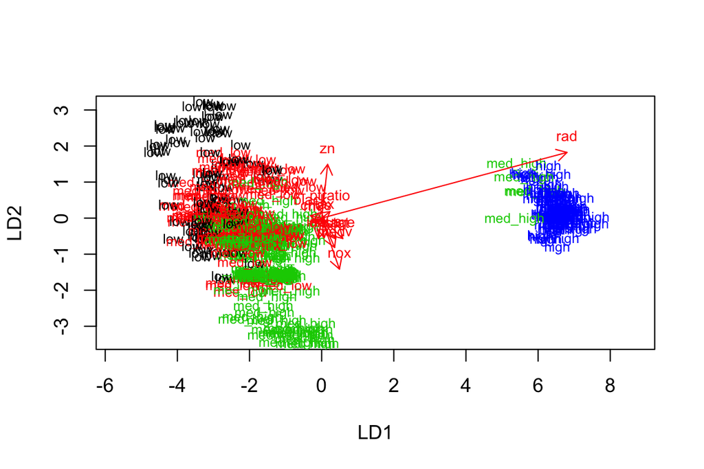

```r
classes <- as.numeric(train$crime)
plot(lda.fit, dimen = 2, col =classes, pch =classes)
lda.arrows(lda.fit, myscale = 2)
```

- The LDA model was fit with crime as the target variable and all the other variables as predictors.
- Since there were four classes through the summary of the LDA model we find **3** linear discriminants.
- Based on the co-efficients of the variables (size of the arrows in the bi-plot) we find the **rad, zinc and nox** are the contributors for highest variance.
- Further **LD1** explains 95% of variance in the predictor varaibles.

#### Prediction on test set:

```r
lda.pred <- predict(lda.fit, newdata = test)
table(correct = true_class, predicted = lda.pred$class)
```

```
##           predicted
## correct    low med_low med_high high
##   low       16      10        0    0
##   med_low    7      15        4    0
##   med_high   1       6       15    1
##   high       0       0        1   26
```

- The LDA model was used to predict the class of in the test dataset.
- Based on the tabulated predictions we find that the LDA model classfiy’s the various classes correctly **70%** of time.
- It is important to note that the train set was random sampled, hence when using a different seed setting this number might change, hence its is advisable to do a cross-validation of the model prior to prediction.

#### Distance and K-means:

```r
data(Boston)
boston_scaled <- scale(Boston)
euc_dist <- dist(boston_scaled)
summary(euc_dist)
```

```
##    Min. 1st Qu.  Median    Mean 3rd Qu.    Max.
##  0.1343  3.4625  4.8241  4.9111  6.1863 14.3970
```

```r
km <-kmeans(boston_scaled, centers = 3)
```

- The boston dataset was reloaded and scaled.
- The distance between various varaibles were enumerated through euclidean distance measure.
- Since assuming the output classes are not known **kmeans** clsuerting was preformed with 3 classes.

#### Optimal number of K-means cluster:

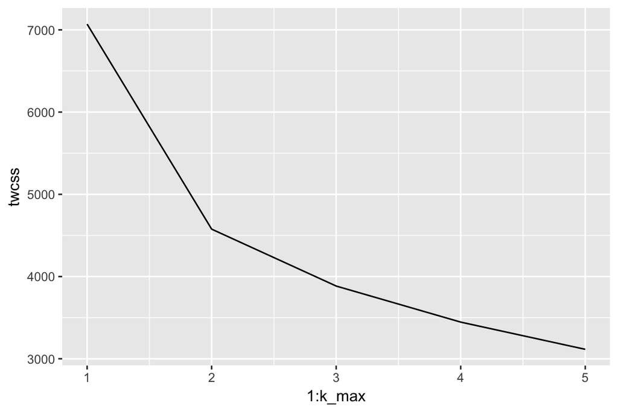

```r
set.seed(123)
k_max <- 5
twcss <- sapply(1:k_max, function(k){kmeans(boston_scaled, k)$tot.withinss})
qplot(x = 1:k_max, y = twcss, geom = 'line')
```

- From the plot it was found the was signiifcant drop in the total within cluster sum of squares **twcss** value after two clusters.
- Hence the **kmeans clustering** was preformed again with two clusters.

[figure not shown]

```r
kmnew <-kmeans(boston_scaled, centers = 2)
pairs(boston_scaled, col = kmnew$cluster)
```

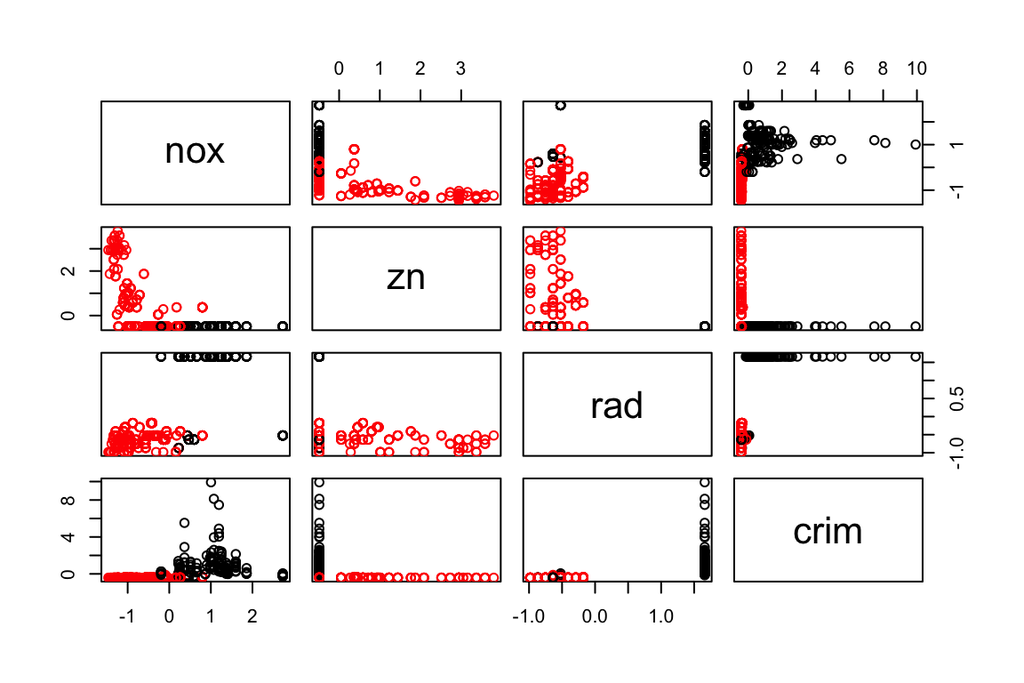

```r
my_var <- c("nox","zn","rad","crim")
pairs(boston_scaled[,my_var], col = kmnew$cluster)
```

- The kmeans clusters were visulaized using a set of selected varaibles **nox,zn,rad,crim**, as they had the highest co-efficents in the LDA anaysis.
- The 2 clusters colour coded in the plot shows a distinct classificiation in the crime rate in the Boston population.

#### Bonus: Clsutering and LDA:

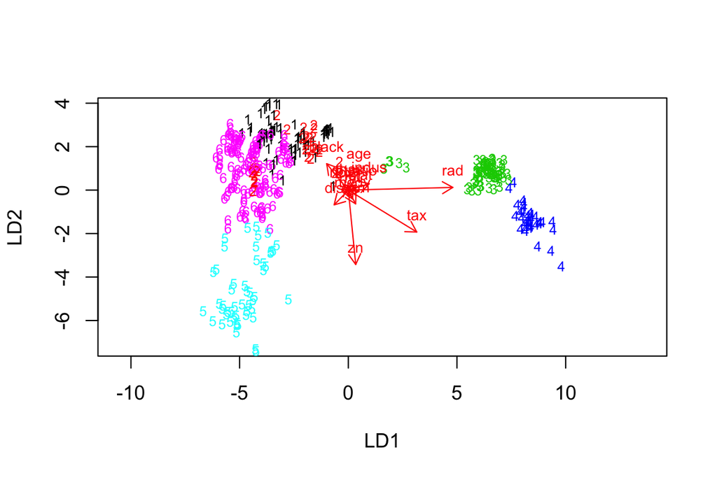

```r
data(Boston)
boston_scaled <- scale(Boston)
boston_scaled <- as.data.frame(boston_scaled)

km <-kmeans(boston_scaled, centers = 6)
cluster <- km$cluster
boston_scaled <- data.frame(boston_scaled,cluster)

set.seed(345)
ind <- sample(nrow(boston_scaled),  size = nrow(boston_scaled) * 0.8)
train <- boston_scaled[ind,]
test <- boston_scaled[-ind,]
t_class <- test$cluster
test <- dplyr::select(test, -cluster)

lfit <- lda(cluster~., data = train)
classes <- as.numeric(train$cluster)
plot(lfit, dimen = 2, col =classes, pch =classes)
lda.arrows(lfit, myscale = 2)
```

```r
lda.pred2 <- predict(lfit, newdata = test)
table(correct = t_class, predicted = lda.pred2$class)
```

```
##        predicted
## correct  1  2  3  4  5  6
##       1 23  0  0  0  0  5
##       2  1 13  0  0  0  1
##       3  0  0 19  0  0  0
##       4  0  0  1  4  0  0
##       5  0  0  0  0  7  1
##       6  0  0  0  0  0 27
```